# Praktikum 2 MPDW

Restu Ramadhani_M0401241047

2026-08-27

# Tugas Praktikum

1. Setiap kelompok memilih satu data time series dengan panjang ≥ 500 periode.
2. Data dibagi rata ke setiap anggota; minimal 100 observasi per orang.
3. Terapkan metode pemulusan yang sudah dipelajari (SMA, DMA, SES, DES, atau Holt-Winters) pada bagian data masing-masing
4. Bandingkan kinerja metode dan tentukan metode terbaik untuk data tersebut menggunakan metrik akurasi (mis. SSE/MSE/RMSE/MAPE), lalu jelaskan alasannya secara singkat.(Upload tugas per individu ke GitHub pada folder `Pertemuan-2` dengan format HTML bernama `Tugas-Pertemuan-2.html`.)
5. Deadline Pengumpulan : **Rabu, 26 Agustus 2026 pukul 23.59 WIB**

# Persiapan Data

## Library/Packages yang digunakan untuk analisis data time series

```r
library("forecast")
library("graphics")
library("TTR")
library("TSA")
library("readr")
library("dplyr")
library("lubridate")
library("ggplot2")
```

```r
# Import Dataset
data <- read_csv("D:\\IPB\\PPT Kuliah - IPB\\Semester 5 Dept Statistika\\MPDW\\Dataset\\dataset praktikum.csv")
data
```

```
## # A tibble: 6,351 × 5
##    Date                 Open  High   Low Close
##    <dttm>              <dbl> <dbl> <dbl> <dbl>
##  1 2001-06-27 23:00:00 11441 11565 11338 11448
##  2 2001-06-28 23:00:00 11370 11510 11265 11390
##  3 2001-07-01 23:00:00 11315 11490 11215 11320
##  4 2001-07-02 23:00:00 11330 11455 11188 11322
##  5 2001-07-03 23:00:00 11355 11465 11251 11365
##  6 2001-07-04 23:00:00 11357 11485 11240 11357
##  7 2001-07-05 23:00:00 11340 11440 11230 11330
##  8 2001-07-08 23:00:00 11330 11433 11223 11330
##  9 2001-07-09 23:00:00 11370 11470 11252 11352
## 10 2001-07-10 23:00:00 11354 11458 11240 11340
## # ℹ 6,341 more rows
```

```r
# Cleaning Dataset (Date Column)
USD_2021 <- data %>%
  mutate(Date = as.Date(substr(Date, 1, 10)))

# Filter data untuk 2021
USD_2021 <- USD_2021 %>%
  filter(year(Date) == 2021) %>%
  select(Date, Close) %>%
  arrange(Date)

str(USD_2021)
```

```
## tibble [261 × 2] (S3: tbl_df/tbl/data.frame)
##  $ Date : Date[1:261], format: "2021-01-01" "2021-01-04" ...
##  $ Close: num [1:261] 13932 14023 13931 13930 13952 ...
```

```r
nrow(USD_2021)
```

```
## [1] 261
```

```r
head(USD_2021)
```

```
## # A tibble: 6 × 2
##   Date        Close
##   <date>      <dbl>
## 1 2021-01-01 13932.
## 2 2021-01-04 14023.
## 3 2021-01-05 13931.
## 4 2021-01-06 13930
## 5 2021-01-07 13952.
## 6 2021-01-08 13893.
```

```r
tail(USD_2021)
```

```
## # A tibble: 6 × 2
##   Date        Close
##   <date>      <dbl>
## 1 2021-12-24 14168.
## 2 2021-12-27 14189.
## 3 2021-12-28 14220
## 4 2021-12-29 14238.
## 5 2021-12-30 14237
## 6 2021-12-31 14285.
```

# Eksplorasi Data

```r
data.ts <-ts(USD_2021$Close)
View(USD_2021)
str(USD_2021)
```

```
## tibble [261 × 2] (S3: tbl_df/tbl/data.frame)
##  $ Date : Date[1:261], format: "2021-01-01" "2021-01-04" ...
##  $ Close: num [1:261] 13932 14023 13931 13930 13952 ...
```

```r
dim(USD_2021)
```

```
## [1] 261   2
```

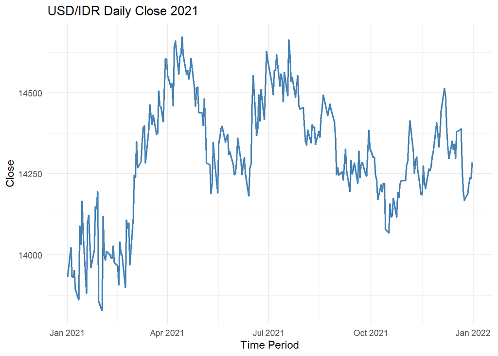

```r
ggplot(USD_2021, aes(x = Date, y = Close)) +
  geom_line(color = "steelblue", linewidth = 0.8) +
  labs(title = "USD/IDR Daily Close 2021",
       x = "Time Period", y = "Close") +
  theme_minimal()
```

# Pembagian Data Pembagian data latih dan data uji dilakukan dengan perbandingan 80% data latih dan 20% data uji.

```r
# hitung jumlah data
n <- nrow(USD_2021)

# tentukan batas 80%
n_train <- floor(0.8 * n)

# bagi data
training_ma <- USD_2021[1:n_train, ]
testing_ma  <- USD_2021[(n_train+1):n, ]

# ubah ke time series
train_ma.ts <- ts(training_ma$Close)
test_ma.ts  <- ts(testing_ma$Close)
```

Eksplorasi data dilakukan pada keseluruhan data, data latih serta data uji menggunakan plot data deret waktu.

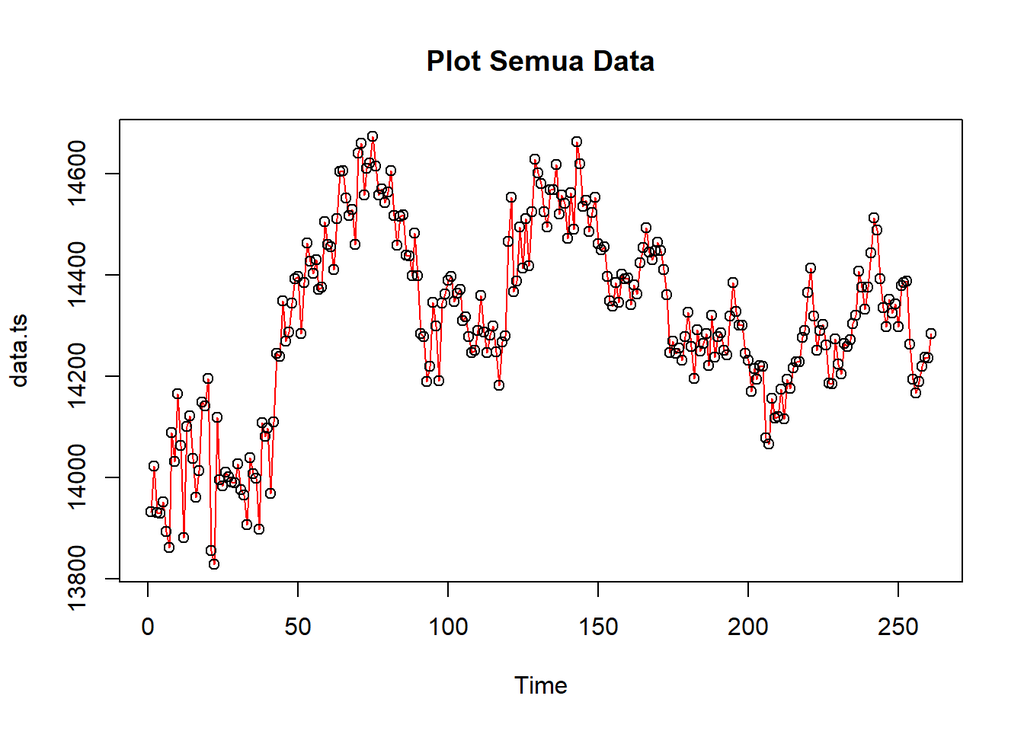

```r
#eksplorasi keseluruhan data
plot(data.ts, col="red",main="Plot Semua Data")
points(data.ts)
```

[figure not shown]

```r
#eksplorasi data latih
plot(data.ts, col="blue",main="Plot Data Latih")
points(data.ts)
```

[figure not shown]

```r
#eksplorasi data uji
plot(data.ts, col="blue",main="Plot Data Uji")
points(data.ts)
```

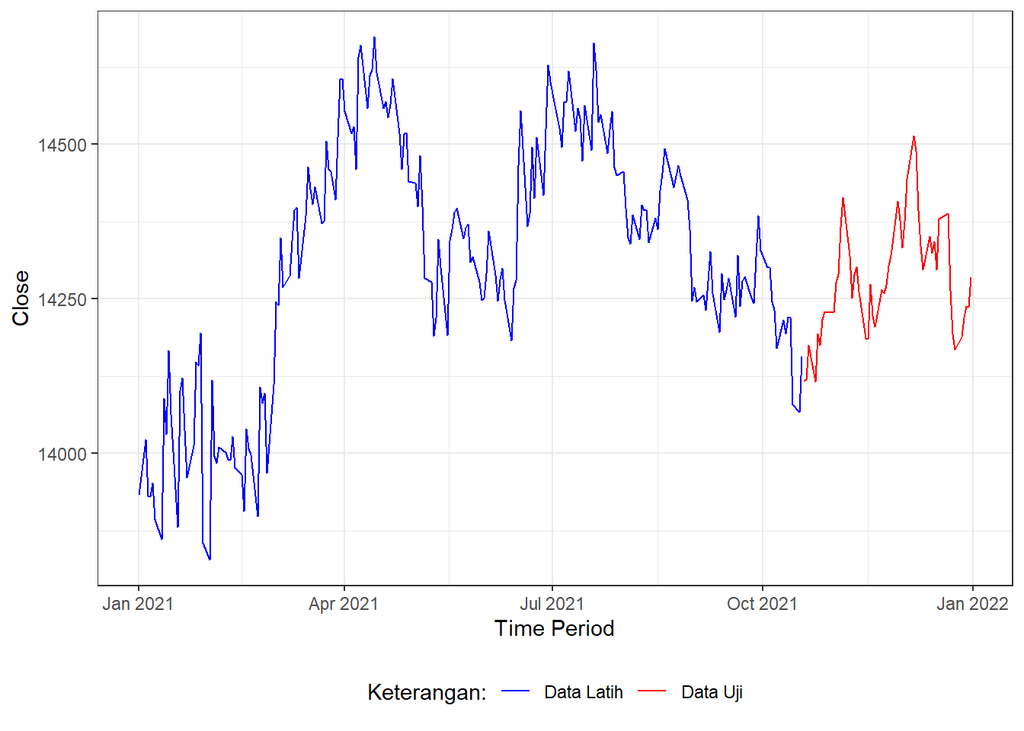

```r
library(ggplot2)
ggplot() +
  geom_line(data = training_ma, aes(x = Date, y = Close, col = "Data Latih")) +
  geom_line(data = testing_ma, aes(x = Date, y = Close, col = "Data Uji")) +
  labs(x = "Time Period", y = "Close", color = "Legend") +
   scale_colour_manual(name="Keterangan:", breaks = c("Data Latih", "Data Uji"),
                      values = c("blue", "red")) +
  theme_bw() + theme(legend.position = "bottom",
                     plot.caption = element_text(hjust=0.5, size=12))
```

# Metode 1: Simple Moving Average (SMA)

```r
data.sma<-SMA(train_ma.ts, n=3)
data.sma
```

```
## Time Series:
## Start = 1
## End = 208
## Frequency = 1
##   [1]       NA       NA 13962.09 13961.30 13937.63 13924.83 13901.96 13947.70
##   [9] 13993.74 14095.27 14086.74 14036.64 14014.91 14034.53 14086.67 14039.99
##  [17] 14003.62 14040.72 14101.13 14161.83 14063.95 13959.33 13933.83 13980.72
##  [25] 14032.66 13996.65 13998.51 14000.68 13993.58 14002.22 13997.48 13989.75
##  [33] 13949.75 13970.73 13984.56 14014.96 13968.03 14001.44 14029.24 14095.70
##  [41] 14049.20 14058.86 14108.13 14198.46 14277.93 14285.69 14301.76 14300.25
##  [49] 14341.62 14378.49 14358.30 14355.70 14377.70 14425.57 14431.50 14420.50
##  [57] 14402.07 14393.00 14417.83 14447.10 14473.97 14442.47 14459.70 14509.23
##  [65] 14574.23 14588.00 14559.00 14533.40 14502.50 14543.50 14587.33 14619.90
##  [73] 14610.20 14597.00 14635.60 14636.97 14615.93 14581.33 14557.07 14559.13
##  [81] 14571.33 14562.93 14528.07 14498.00 14498.33 14491.70 14465.57 14425.60
##  [89] 14439.87 14427.03 14388.60 14320.43 14250.47 14229.20 14252.20 14289.10
##  [97] 14279.43 14278.60 14299.27 14365.50 14383.10 14378.33 14370.10 14361.47
## [105] 14348.80 14333.13 14302.00 14281.17 14259.00 14263.23 14300.73 14312.90
## [113] 14298.17 14271.83 14275.83 14276.50 14243.50 14232.67 14243.27 14338.10
## [121] 14433.83 14463.07 14437.17 14417.27 14432.37 14473.17 14447.50 14484.73
## [129] 14524.03 14585.23 14604.03 14569.67 14534.13 14529.90 14544.30 14585.53
## [137] 14569.63 14566.07 14540.53 14524.53 14526.03 14509.00 14572.83 14591.83
## [145] 14606.83 14568.23 14523.57 14519.40 14521.17 14513.37 14488.87 14456.20
## [153] 14434.47 14400.97 14361.83 14357.87 14356.70 14377.87 14380.40 14396.73
## [161] 14376.37 14372.33 14361.67 14389.70 14414.10 14457.57 14464.53 14456.47
## [169] 14441.57 14448.13 14454.57 14442.00 14407.43 14339.83 14292.57 14253.73
## [177] 14256.90 14244.30 14255.53 14279.00 14288.13 14260.40 14248.80 14245.77
## [185] 14268.60 14266.03 14256.47 14275.13 14259.67 14279.07 14267.73 14272.23
## [193] 14260.00 14270.70 14315.37 14344.07 14338.20 14310.03 14282.50 14259.63
## [201] 14216.40 14206.40 14193.60 14210.40 14211.63 14173.13 14121.73 14100.90
```

```r
data.ramal<-c(NA,data.sma)
data.ramal
```

```
##   [1]       NA       NA       NA 13962.09 13961.30 13937.63 13924.83 13901.96
##   [9] 13947.70 13993.74 14095.27 14086.74 14036.64 14014.91 14034.53 14086.67
##  [17] 14039.99 14003.62 14040.72 14101.13 14161.83 14063.95 13959.33 13933.83
##  [25] 13980.72 14032.66 13996.65 13998.51 14000.68 13993.58 14002.22 13997.48
##  [33] 13989.75 13949.75 13970.73 13984.56 14014.96 13968.03 14001.44 14029.24
##  [41] 14095.70 14049.20 14058.86 14108.13 14198.46 14277.93 14285.69 14301.76
##  [49] 14300.25 14341.62 14378.49 14358.30 14355.70 14377.70 14425.57 14431.50
##  [57] 14420.50 14402.07 14393.00 14417.83 14447.10 14473.97 14442.47 14459.70
##  [65] 14509.23 14574.23 14588.00 14559.00 14533.40 14502.50 14543.50 14587.33
##  [73] 14619.90 14610.20 14597.00 14635.60 14636.97 14615.93 14581.33 14557.07
##  [81] 14559.13 14571.33 14562.93 14528.07 14498.00 14498.33 14491.70 14465.57
##  [89] 14425.60 14439.87 14427.03 14388.60 14320.43 14250.47 14229.20 14252.20
##  [97] 14289.10 14279.43 14278.60 14299.27 14365.50 14383.10 14378.33 14370.10
## [105] 14361.47 14348.80 14333.13 14302.00 14281.17 14259.00 14263.23 14300.73
## [113] 14312.90 14298.17 14271.83 14275.83 14276.50 14243.50 14232.67 14243.27
## [121] 14338.10 14433.83 14463.07 14437.17 14417.27 14432.37 14473.17 14447.50
## [129] 14484.73 14524.03 14585.23 14604.03 14569.67 14534.13 14529.90 14544.30
## [137] 14585.53 14569.63 14566.07 14540.53 14524.53 14526.03 14509.00 14572.83
## [145] 14591.83 14606.83 14568.23 14523.57 14519.40 14521.17 14513.37 14488.87
## [153] 14456.20 14434.47 14400.97 14361.83 14357.87 14356.70 14377.87 14380.40
## [161] 14396.73 14376.37 14372.33 14361.67 14389.70 14414.10 14457.57 14464.53
## [169] 14456.47 14441.57 14448.13 14454.57 14442.00 14407.43 14339.83 14292.57
## [177] 14253.73 14256.90 14244.30 14255.53 14279.00 14288.13 14260.40 14248.80
## [185] 14245.77 14268.60 14266.03 14256.47 14275.13 14259.67 14279.07 14267.73
## [193] 14272.23 14260.00 14270.70 14315.37 14344.07 14338.20 14310.03 14282.50
## [201] 14259.63 14216.40 14206.40 14193.60 14210.40 14211.63 14173.13 14121.73
## [209] 14100.90
```

Selanjutnya dilakukan peramalan sebanyak 53 periode sesuai dengan jumlah data uji. Pada metode SMA, seluruh hasil peramalan untuk 53 periode ke depan akan memiliki nilai yang sama dengan hasil ramalan satu periode ke depan.

```r
data.gab<-cbind(
  aktual=c(data.ts),
  pemulusan=c(data.sma,rep(NA,53)),
  ramalan=c(data.ramal,rep(data.ramal[length(data.ramal)],52)))

data.gab #forecast 53 periode ke depan
```

```
##          aktual pemulusan  ramalan
##   [1,] 13932.37        NA       NA
##   [2,] 14022.50        NA       NA
##   [3,] 13931.40  13962.09       NA
##   [4,] 13930.00  13961.30 13962.09
##   [5,] 13951.50  13937.63 13961.30
##   [6,] 13892.98  13924.83 13937.63
##   [7,] 13861.39  13901.96 13924.83
##   [8,] 14088.74  13947.70 13901.96
##   [9,] 14031.08  13993.74 13947.70
##  [10,] 14166.00  14095.27 13993.74
##  [11,] 14063.15  14086.74 14095.27
##  [12,] 13880.78  14036.64 14086.74
##  [13,] 14100.80  14014.91 14036.64
##  [14,] 14122.00  14034.53 14014.91
```

[output cut: 247 more lines]

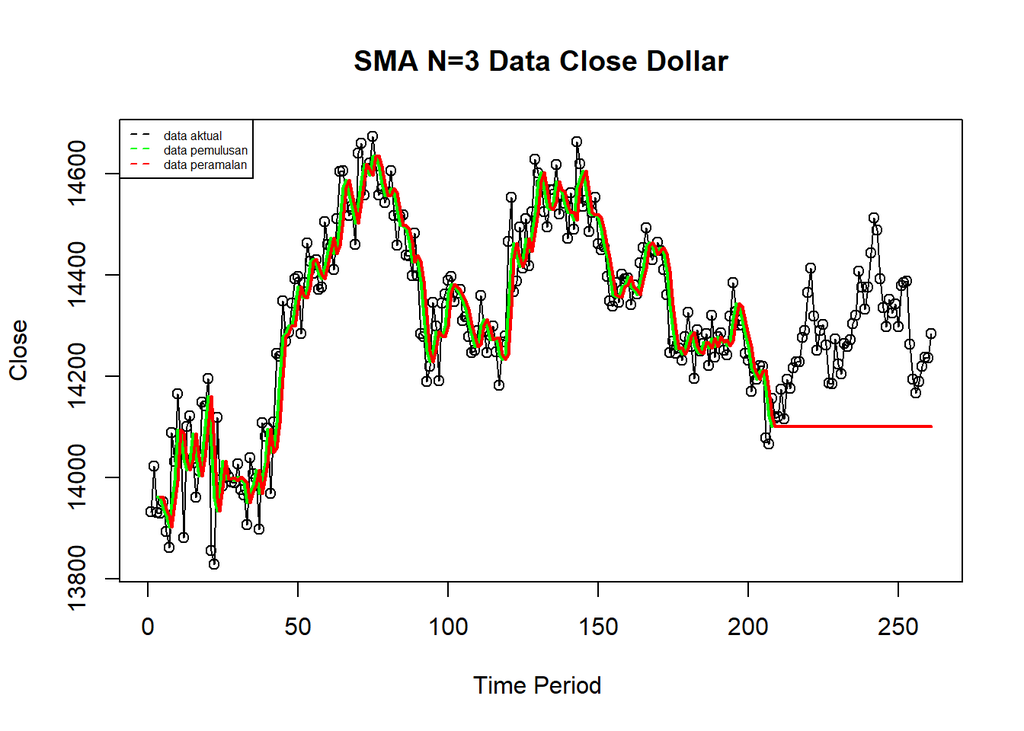

```r
ts.plot(data.ts, xlab="Time Period ", ylab="Close", main= "SMA N=3 Data Close Dollar")
points(data.ts)
lines(data.gab[,2],col="green",lwd=2)
lines(data.gab[,3],col="red",lwd=2)
legend("topleft",c("data aktual","data pemulusan","data peramalan"), lty=8, col=c("black","green","red"), cex=0.5)
```

Selanjutnya perhitungan akurasi dilakukan dengan ukuran akurasi Sum Squares Error (SSE), Mean Square Error (MSE) dan Mean Absolute Percentage Error (MAPE). Perhitungan akurasi dilakukan baik pada data latih maupun pada data uji.

```r
#Menghitung nilai keakuratan data latih
error_train.sma = train_ma.ts-data.ramal[1:length(train_ma.ts)]

SSE_train.sma = sum(error_train.sma[5:length(train_ma.ts)]^2)
MSE_train.sma = mean(error_train.sma[5:length(train_ma.ts)]^2)
MAPE_train.sma = mean(abs((error_train.sma[5:length(train_ma.ts)]/train_ma.ts[5:length(train_ma.ts)])*100))

akurasi_train.sma <- matrix(c(SSE_train.sma, MSE_train.sma, MAPE_train.sma))
row.names(akurasi_train.sma)<- c("SSE", "MSE", "MAPE")
colnames(akurasi_train.sma) <- c("Akurasi m = 3")
akurasi_train.sma
```

```
##      Akurasi m = 3
## SSE   1.261710e+06
## MSE   6.184850e+03
## MAPE  4.226967e-01
```

```r
#Menghitung nilai keakuratan data uji
error_test.sma = test_ma.ts-data.gab[209:261,3]

SSE_test.sma = sum(error_test.sma^2)
MSE_test.sma = mean(error_test.sma^2)
MAPE_test.sma = mean(abs((error_test.sma/test_ma.ts*100)))

akurasi_test.sma <- matrix(c(SSE_test.sma, MSE_test.sma, MAPE_test.sma))
row.names(akurasi_test.sma)<- c("SSE", "MSE", "MAPE")
colnames(akurasi_test.sma) <- c("Akurasi m = 3")
akurasi_test.sma
```

```
##      Akurasi m = 3
## SSE   2.219298e+06
## MSE   4.187355e+04
## MAPE  1.280644e+00
```

Perhitungan akurasi menggunakan data latih menghasilkan nilai MAPE yang kurang dari 10% sehingga nilai akurasi ini dapat dikategorikan sebagai sangat baik.

# Metode 2: Double Moving Average (DMA)

```r
dma <- SMA(data.sma, n = 3)
At <- 2*data.sma - dma
Bt <- 2/(3-1)*(data.sma - dma)
data.dma<- At+Bt
data.ramal2<- c(NA, data.dma)

t = 1:53
f = c()

for (i in t) {
  f[i] = At[length(At)] + Bt[length(Bt)]*(i)
}

data.gab2 <- cbind(aktual = c(data.ts),
                   pemulusan1 = c(data.sma,rep(NA,53)),
                   pemulusan2 = c(dma, rep(NA,53)),
                   At = c(At, rep(NA,53)),
                   Bt = c(Bt,rep(NA,53)),
                   ramalan = c(data.ramal2, f[-1]))
data.gab2
```

```
##          aktual pemulusan1 pemulusan2       At           Bt  ramalan
##   [1,] 13932.37         NA         NA       NA           NA       NA
##   [2,] 14022.50         NA         NA       NA           NA       NA
##   [3,] 13931.40   13962.09         NA       NA           NA       NA
##   [4,] 13930.00   13961.30         NA       NA           NA       NA
##   [5,] 13951.50   13937.63   13953.68 13921.59  -16.0417752       NA
##   [6,] 13892.98   13924.83   13941.25 13908.40  -16.4274089 13905.55
##   [7,] 13861.39   13901.96   13921.47 13882.44  -19.5152995 13891.97
##   [8,] 14088.74   13947.70   13924.83 13970.58   22.8736979 13862.93
##   [9,] 14031.08   13993.74   13947.80 14039.67   45.9373915 13993.45
##  [10,] 14166.00   14095.27   14012.24 14178.31   83.0350477 14085.61
##  [11,] 14063.15   14086.74   14058.58 14114.90   28.1590712 14261.34
##  [12,] 13880.78   14036.64   14072.89 14000.40  -36.2428385 14143.06
##  [13,] 14100.80   14014.91   14046.10 13983.72  -31.1888021 13964.16
##  [14,] 14122.00   14034.53   14028.69 14040.36    5.8338759 13952.53
```

[output cut: 247 more lines]

Hasil pemulusan menggunakan metode DMA divisualisasikan sebagai berikut

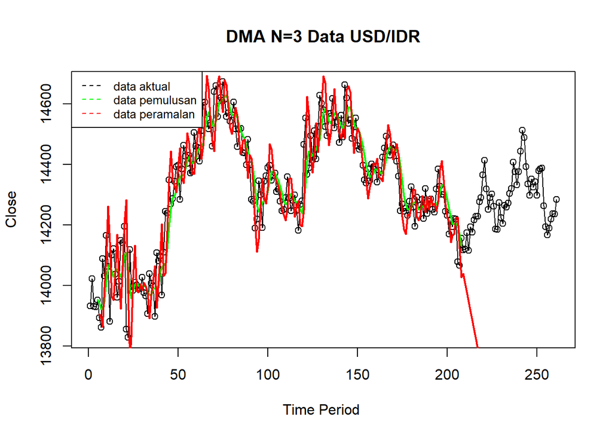

```r
ts.plot(data.ts, xlab="Time Period ", ylab="Close", main= "DMA N=3 Data USD/IDR")
points(data.ts)
lines(data.gab2[,3],col="green",lwd=2)
lines(data.gab2[,6],col="red",lwd=2)
legend("topleft",c("data aktual","data pemulusan","data peramalan"), lty=8, col=c("black","green","red"), cex=0.8)
```

Selanjutnya perhitungan akurasi dilakukan baik pada data latih maupun data uji. Perhitungan akurasi dilakukan dengan ukuran akurasi SSE, MSE dan MAPE.

```r
error_train.dma = train_ma.ts-data.ramal2[1:length(train_ma.ts)]

SSE_train.dma = sum(error_train.dma[8:length(train_ma.ts)]^2)
MSE_train.dma = mean(error_train.dma[8:length(train_ma.ts)]^2)
MAPE_train.dma = mean(abs((error_train.dma[8:length(train_ma.ts)]/train_ma.ts[8:length(train_ma.ts)])*100))

akurasi_train.dma <- matrix(c(SSE_train.dma, MSE_train.dma, MAPE_train.dma))
row.names(akurasi_train.dma)<- c("SSE", "MSE", "MAPE")
colnames(akurasi_train.dma) <- c("Akurasi m = 3")
akurasi_train.dma
```

```
##      Akurasi m = 3
## SSE   1.998671e+06
## MSE   9.943635e+03
## MAPE  5.219975e-01
```

Perhitungan akurasi pada data latih menggunakan nilai MAPE menghasilkan nilai MAPE yang kurang dari 10% sehingga dikategorikan sangat baik. Selanjutnya, perhitungan nilai akurasi dilakukan pada data uji.

```r
error_test.dma = test_ma.ts-data.gab2[209:261,6]
SSE_test.dma = sum(error_test.dma^2)
MSE_test.dma = mean(error_test.dma^2)
MAPE_test.dma = mean(abs((error_test.dma/test_ma.ts*100)))

akurasi_test.dma <- matrix(c(SSE_test.dma, MSE_test.dma, MAPE_test.dma))
row.names(akurasi_test.dma)<- c("SSE", "MSE", "MAPE")
colnames(akurasi_test.dma) <- c("Akurasi m = 3")
akurasi_test.dma
```

```
##      Akurasi m = 3
## SSE   7.264344e+07
## MSE   1.370631e+06
## MAPE  7.354370e+00
```

Perhitungan akurasi menggunakan data latih menghasilkan nilai MAPE yang kurang dari 10% sehingga nilai akurasi ini dapat dikategorikan sebagai sangat baik. Pada kedua data metode SMA lebih baik dibandingkan dengan metode DMA.

## Pembagian Data

Pembagian data latih dan data uji dilakukan dengan perbandingan 80% data latih dan 20% data uji.

```r
# jumlah baris data
n <- nrow(USD_2021)

# hitung batas 80%
n_train <- floor(0.8 * n)

# bagi data
training <- USD_2021[1:n_train, ]
testing  <- USD_2021[(n_train+1):n, ]

# ubah ke time series
train.ts <- ts(training$Close)
test.ts  <- ts(testing$Close)
```

# Metode 3: Simple Exponential Smoothing (SES)

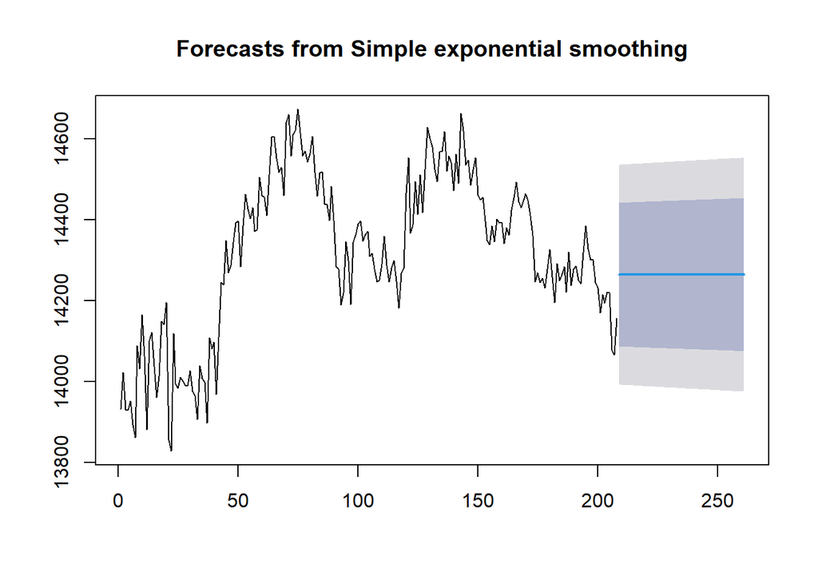

```r
#Cara 1 (fungsi ses)
ses.1 <- ses(train.ts, h = 53, alpha = 0.05)
plot(ses.1)
```

```r
ses.1
```

```
##     Point Forecast    Lo 80    Hi 80    Lo 95    Hi 95
## 209        14264.5 14086.55 14442.44 13992.35 14536.64
## 210        14264.5 14086.33 14442.66 13992.01 14536.98
## 211        14264.5 14086.11 14442.88 13991.67 14537.32
## 212        14264.5 14085.89 14443.11 13991.33 14537.66
## 213        14264.5 14085.66 14443.33 13991.00 14538.00
## 214        14264.5 14085.44 14443.55 13990.66 14538.33
## 215        14264.5 14085.22 14443.77 13990.32 14538.67
## 216        14264.5 14085.00 14443.99 13989.98 14539.01
## 217        14264.5 14084.78 14444.21 13989.65 14539.35
## 218        14264.5 14084.56 14444.43 13989.31 14539.68
## 219        14264.5 14084.34 14444.65 13988.97 14540.02
## 220        14264.5 14084.12 14444.87 13988.64 14540.35
## 221        14264.5 14083.90 14445.09 13988.30 14540.69
## 222        14264.5 14083.68 14445.31 13987.97 14541.02
```

[output cut: 39 more lines]

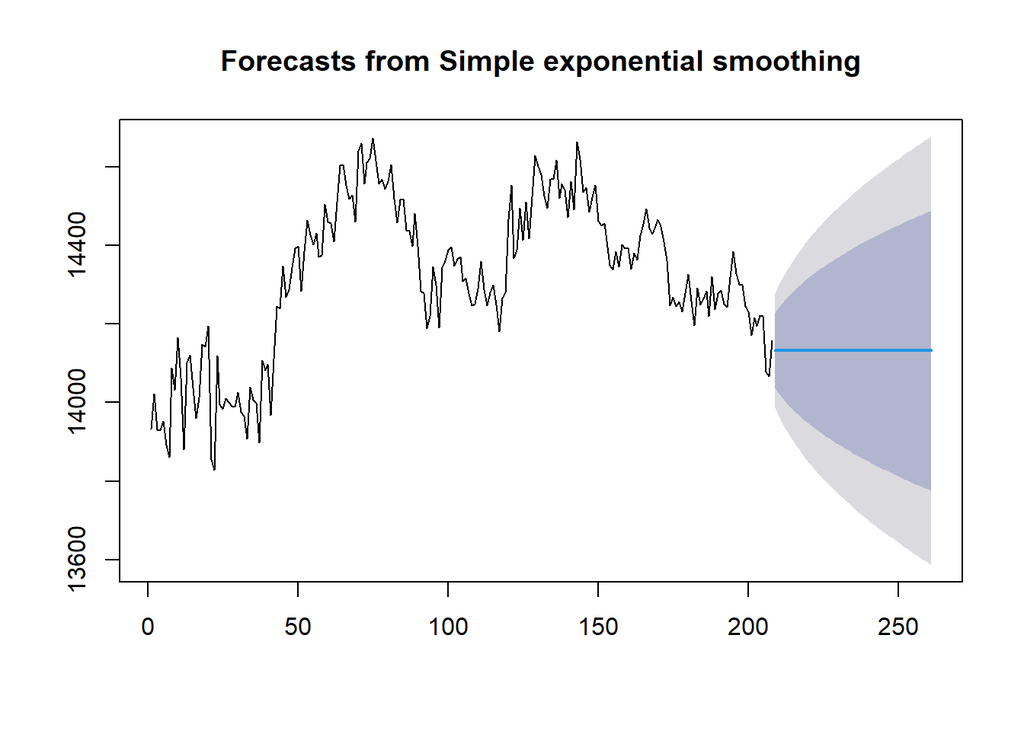

```r
ses.2<- ses(train.ts, h = 53, alpha = 0.5)
plot(ses.2)
```

```r
ses.2
```

```
##     Point Forecast    Lo 80    Hi 80    Lo 95    Hi 95
## 209       14132.19 14036.96 14227.42 13986.55 14277.83
## 210       14132.19 14025.72 14238.66 13969.36 14295.02
## 211       14132.19 14015.56 14248.82 13953.82 14310.56
## 212       14132.19 14006.21 14258.16 13939.53 14324.85
## 213       14132.19 13997.51 14266.86 13926.22 14338.15
## 214       14132.19 13989.35 14275.03 13913.73 14350.65
## 215       14132.19 13981.62 14282.76 13901.91 14362.46
## 216       14132.19 13974.27 14290.11 13890.67 14373.70
## 217       14132.19 13967.25 14297.13 13879.93 14384.44
## 218       14132.19 13960.51 14303.86 13869.63 14394.74
## 219       14132.19 13954.03 14310.34 13859.72 14404.65
## 220       14132.19 13947.78 14316.60 13850.16 14414.22
## 221       14132.19 13941.73 14322.64 13840.91 14423.47
## 222       14132.19 13935.87 14328.51 13831.94 14432.43
```

[output cut: 39 more lines]

Pada fungsi ses() , terdapat beberapa argumen yang umum digunakan, yaitu

y : nilai data deret waktu alpha : parameter pemulusan utama (0–1), mengatur bobot data terbaru vs data lama. beta : parameter pemulusan tren. gamma : parameter pemulusan musiman. h : jumlah periode ke depan yang ingin diramalkan (forecast horizon).

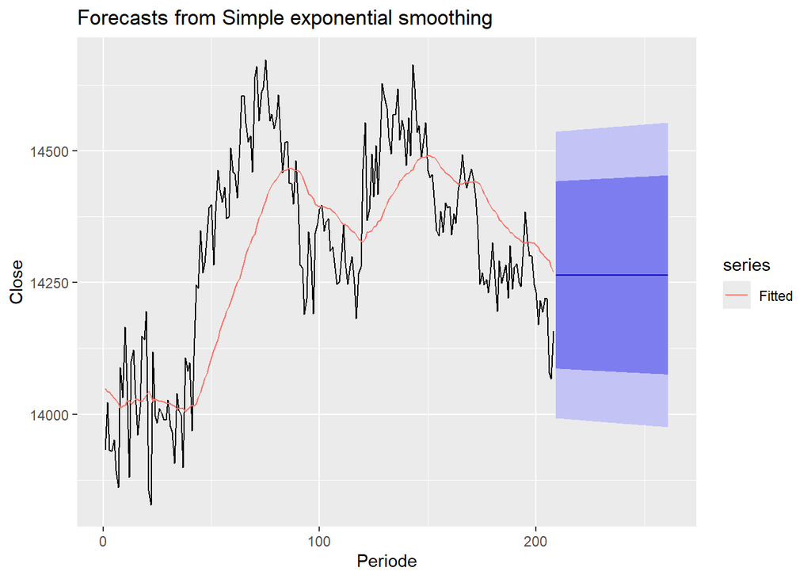

```r
autoplot(ses.1) +
  autolayer(fitted(ses.1), series="Fitted") +
  ylab("Close") + xlab("Periode")
```

Selanjutnya akan digunakan fungsi HoltWinters() dengan nilai inisialisasi parameter dan panjang periode peramalan yang sama dengan fungsi ses() .

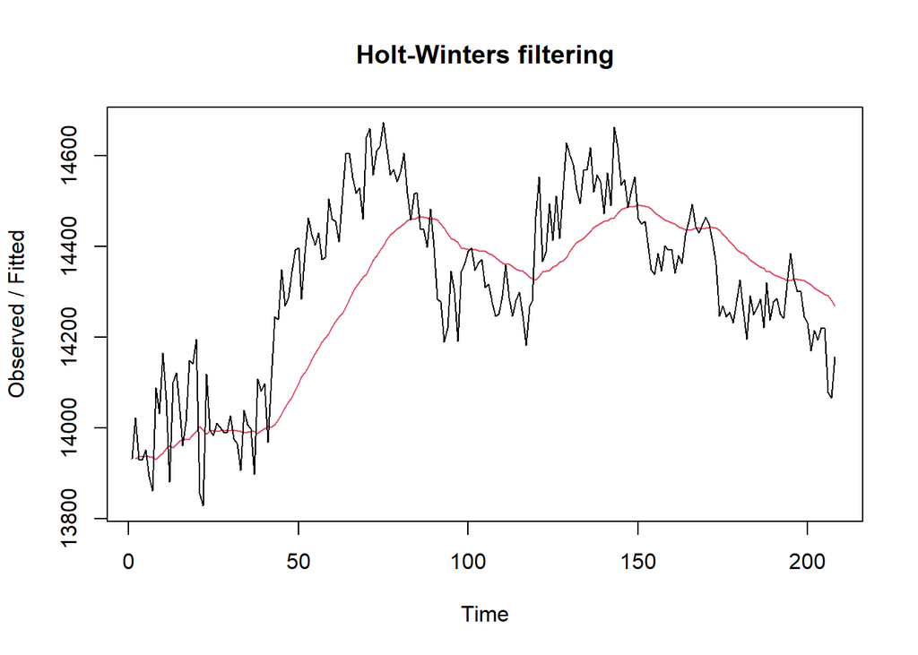

```r
#Cara 2 (fungsi Holtwinter)
ses1<- HoltWinters(train.ts, gamma = FALSE, beta = FALSE, alpha = 0.05)
plot(ses1)
```

```r
ramalan1<- forecast(ses1, h=53)
ramalan1
```

```
##     Point Forecast    Lo 80    Hi 80    Lo 95    Hi 95
## 209       14264.49 14088.24 14440.75 13994.93 14534.05
## 210       14264.49 14088.02 14440.97 13994.59 14534.39
## 211       14264.49 14087.80 14441.19 13994.26 14534.73
## 212       14264.49 14087.58 14441.41 13993.92 14535.06
## 213       14264.49 14087.36 14441.63 13993.59 14535.40
## 214       14264.49 14087.14 14441.85 13993.25 14535.73
## 215       14264.49 14086.92 14442.07 13992.92 14536.07
## 216       14264.49 14086.70 14442.29 13992.58 14536.40
## 217       14264.49 14086.48 14442.50 13992.25 14536.74
## 218       14264.49 14086.26 14442.72 13991.92 14537.07
## 219       14264.49 14086.05 14442.94 13991.58 14537.40
## 220       14264.49 14085.83 14443.16 13991.25 14537.74
## 221       14264.49 14085.61 14443.37 13990.92 14538.07
## 222       14264.49 14085.39 14443.59 13990.59 14538.40
```

[output cut: 39 more lines]

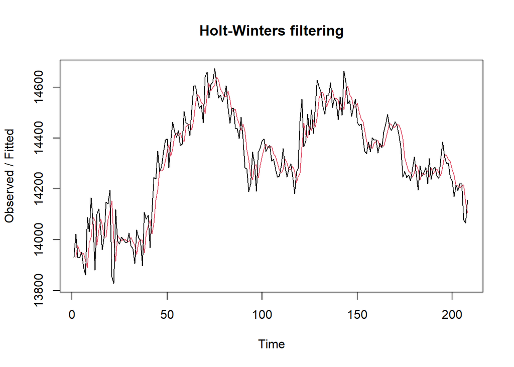

```r
ses2<- HoltWinters(train.ts, gamma = FALSE, beta = FALSE, alpha = 0.5)
plot(ses2)
```

```r
ramalan2<- forecast(ses2, h=53)
ramalan2
```

```
##     Point Forecast    Lo 80    Hi 80    Lo 95    Hi 95
## 209       14132.19 14036.96 14227.41 13986.55 14277.82
## 210       14132.19 14025.72 14238.65 13969.36 14295.01
## 211       14132.19 14015.56 14248.81 13953.82 14310.55
## 212       14132.19 14006.22 14258.16 13939.53 14324.84
## 213       14132.19 13997.52 14266.86 13926.23 14338.15
## 214       14132.19 13989.35 14275.03 13913.74 14350.64
## 215       14132.19 13981.62 14282.75 13901.92 14362.46
## 216       14132.19 13974.27 14290.10 13890.68 14373.69
## 217       14132.19 13967.25 14297.12 13879.94 14384.43
## 218       14132.19 13960.52 14303.86 13869.64 14394.73
## 219       14132.19 13954.04 14310.34 13859.73 14404.64
## 220       14132.19 13947.79 14316.59 13850.17 14414.21
## 221       14132.19 13941.74 14322.64 13840.92 14423.46
## 222       14132.19 13935.88 14328.50 13831.95 14432.42
```

[output cut: 39 more lines]

Fungsi `HoltWinters` memiliki argumen yang sama dengan fungsi `ses()` . Argumen-argumen kedua fungsi dapat dilihat lebih lanjut dengan `?ses()` atau `?HoltWinters` .

Nilai parameter $\alpha$ dari kedua fungsi dapat dioptimalkan menyesuaikan dari *error*-nya paling minimumnya. Caranya adalah dengan membuat parameter $\alpha =$ `NULL` .

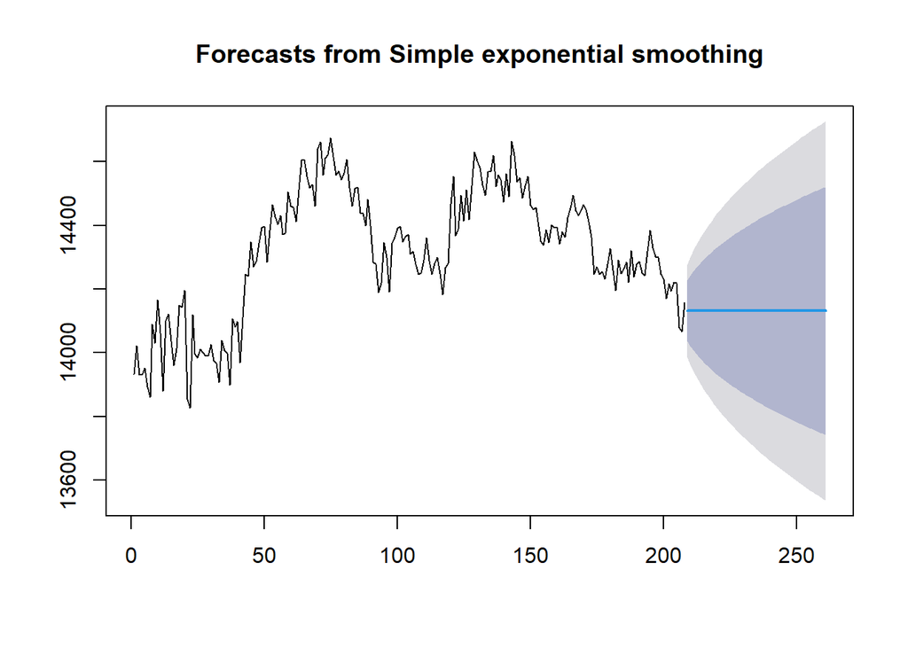

```r
#SES
ses.opt <- ses(train.ts, h = 53, alpha = NULL)
plot(ses.opt)
```

```r
ses.opt
```

```
##     Point Forecast    Lo 80    Hi 80    Lo 95    Hi 95
## 209       14131.51 14036.41 14226.61 13986.07 14276.96
## 210       14131.51 14022.97 14240.05 13965.51 14297.51
## 211       14131.51 14011.02 14252.01 13947.24 14315.79
## 212       14131.51 14000.15 14262.87 13930.62 14332.41
## 213       14131.51 13990.12 14272.91 13915.27 14347.76
## 214       14131.51 13980.75 14282.28 13900.94 14362.09
## 215       14131.51 13971.93 14291.10 13887.45 14375.58
## 216       14131.51 13963.57 14299.45 13874.67 14388.36
## 217       14131.51 13955.61 14307.41 13862.50 14400.53
## 218       14131.51 13948.00 14315.03 13850.85 14412.18
## 219       14131.51 13940.69 14322.34 13839.67 14423.36
## 220       14131.51 13933.64 14329.38 13828.90 14434.13
## 221       14131.51 13926.84 14336.18 13818.50 14444.53
## 222       14131.51 13920.26 14342.76 13808.43 14454.59
```

[output cut: 39 more lines]

```r
#Lamda Optimum Holt Winter
HWopt<- HoltWinters(train.ts, gamma = FALSE, beta = FALSE,alpha = NULL)
HWopt
```

```
## Holt-Winters exponential smoothing without trend and without seasonal component.
##
## Call:
## HoltWinters(x = train.ts, alpha = NULL, beta = FALSE, gamma = FALSE)
##
## Smoothing parameters:
##  alpha: 0.5507645
##  beta : FALSE
##  gamma: FALSE
##
## Coefficients:
##       [,1]
## a 14131.51
```

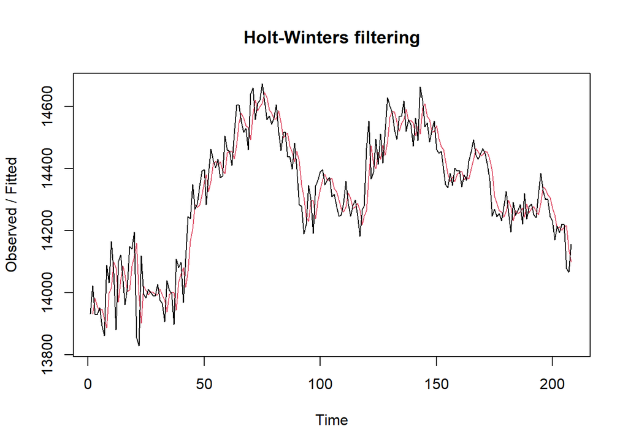

```r
plot(HWopt)
```

```r
#ramalan
ramalanopt<- forecast(HWopt, h=53)
ramalanopt
```

```
##     Point Forecast    Lo 80    Hi 80    Lo 95    Hi 95
## 209       14131.51 14036.41 14226.61 13986.07 14276.95
## 210       14131.51 14022.94 14240.08 13965.47 14297.55
## 211       14131.51 14010.97 14252.06 13947.16 14315.87
## 212       14131.51 14000.08 14262.94 13930.51 14332.52
## 213       14131.51 13990.03 14272.99 13915.13 14347.89
## 214       14131.51 13980.64 14282.38 13900.78 14362.24
## 215       14131.51 13971.81 14291.21 13887.27 14375.75
## 216       14131.51 13963.44 14299.58 13874.47 14388.55
## 217       14131.51 13955.47 14307.55 13862.28 14400.75
## 218       14131.51 13947.84 14315.18 13850.61 14412.41
## 219       14131.51 13940.52 14322.50 13839.41 14423.61
## 220       14131.51 13933.47 14329.56 13828.63 14434.39
## 221       14131.51 13926.66 14336.36 13818.22 14444.81
## 222       14131.51 13920.07 14342.95 13808.14 14454.89
```

[output cut: 39 more lines]

Setelah dilakukan peramalan, akan dilakukan perhitungan keakuratan hasil peramalan. Perhitungan akurasi ini dilakukan baik pada data latih dan data uji. Perhitungan akurasi data dapat dilakukan dengan cara langsung maupun manual. Secara langsung, nilai akurasi dapat diambil dari objek yang tersimpan pada hasil SES, yaitu sum of squared errors (SSE). Nilai akurasi lain dapat dihitung pula dari nilai SSE tersebut.

#### Akurasi Data Latih

Perhitungan akurasi data dapat dilakukan dengan cara langsung maupun manual. Secara langsung, nilai akurasi dapat diambil dari objek yang tersimpan pada hasil SES, yaitu *sum of squared errors* (SSE). Nilai akurasi lain dapat dihitung pula dari nilai SSE tersebut.

```r
SSE1<-ses1$SSE
MSE1<-ses1$SSE/length(train.ts)
RMSE1<-sqrt(MSE1)

akurasi1 <- matrix(c(SSE1,MSE1,RMSE1))
row.names(akurasi1)<- c("SSE", "MSE", "RMSE")
colnames(akurasi1) <- c("Akurasi lamda=0.05")
akurasi1
```

```
##      Akurasi lamda=0.05
## SSE        4109753.2668
## MSE          19758.4292
## RMSE           140.5647
```

```r
SSE1<-ses1$SSE
SSE1
```

```
## [1] 4109753
```

```r
SSE2<-ses2$SSE
MSE2<-ses2$SSE/length(train.ts)
RMSE2<-sqrt(MSE2)

akurasi2 <- matrix(c(SSE2,MSE2,RMSE2))
row.names(akurasi2)<- c("SSE", "MSE", "RMSE")
colnames(akurasi2) <- c("Akurasi lamda=0.5")
akurasi2
```

```
##      Akurasi lamda=0.5
## SSE       1.138133e+06
## MSE       5.471791e+03
## RMSE      7.397156e+01
```

```r
#Cara Manual
# Alpha = 0.2
fitted1<-ramalan1$fitted
sisaan1<-ramalan1$residuals
head(sisaan1)
```

```
## Time Series:
## Start = 1
## End = 6
## Frequency = 1
## [1]         NA  90.126953  -5.479980  -6.606372  15.223947 -44.059712
```

```r
resid1<-training$Close-ramalan1$fitted
head(resid1)
```

```
## Time Series:
## Start = 1
## End = 6
## Frequency = 1
## [1]         NA  90.126953  -5.479980  -6.606372  15.223947 -44.059712
```

```r
SSE.1=sum(sisaan1[2:length(train.ts)]^2)
SSE.1
```

```
## [1] 4109753
```

```r
MSE.1 = SSE.1/length(train.ts)
MSE.1
```

```
## [1] 19758.43
```

```r
MAPE.1 = sum(abs(sisaan1[2:length(train.ts)]/train.ts[2:length(train.ts)])*
               100)/length(train.ts)
MAPE.1
```

```
## [1] 0.783542
```

```r
akurasi.1 <- matrix(c(SSE.1,MSE.1,MAPE.1))
row.names(akurasi.1)<- c("SSE", "MSE", "MAPE")
colnames(akurasi.1) <- c("Akurasi lamda=0.2")
akurasi.1
```

[output not shown]

```r
fitted2<-ramalan2$fitted
sisaan2<-ramalan2$residuals
head(sisaan2)
```

```
## Time Series:
## Start = 1
## End = 6
## Frequency = 1
## [1]         NA  90.126953 -46.037109 -24.418945   9.290527 -53.877197
```

```r
resid2<-training$Close-ramalan2$fitted
head(resid2)
```

```
## Time Series:
## Start = 1
## End = 6
## Frequency = 1
## [1]         NA  90.126953 -46.037109 -24.418945   9.290527 -53.877197
```

```r
SSE.2=sum(sisaan2[2:length(train.ts)]^2)
SSE.2
```

```
## [1] 1138133
```

```r
MSE.2 = SSE.2/length(train.ts)
MSE.2
```

```
## [1] 5471.791
```

```r
MAPE.2 = sum(abs(sisaan2[2:length(train.ts)]/train.ts[2:length(train.ts)])*
               100)/length(train.ts)
MAPE.2
```

```
## [1] 0.3956376
```

```r
akurasi.2 <- matrix(c(SSE.2,MSE.2,MAPE.2))
row.names(akurasi.2)<- c("SSE", "MSE", "MAPE")
colnames(akurasi.2) <- c("Akurasi lamda=0.7")
akurasi.2
```

[output not shown]

Akurasi data uji dapat dihitung dengan cara yang hampir sama dengan perhitungan akurasi data latih.

```r
n_test <- nrow(testing)

# error (ramalan - aktual), samakan panjang dan tipe numeric
e1   <- as.numeric(ramalan1$mean)[1:n_test] - as.numeric(testing$Close)
e2   <- as.numeric(ramalan2$mean)[1:n_test] - as.numeric(testing$Close)
eopt <- as.numeric(ramalanopt$mean)[1:n_test] - as.numeric(testing$Close)

# SSE / MSE / RMSE untuk masing-masing model (abaikan NA)
SSEtesting1  <- sum(e1^2,  na.rm = TRUE)
MSEtesting1  <- mean(e1^2, na.rm = TRUE)
RMSEtesting1 <- sqrt(MSEtesting1)

SSEtesting2  <- sum(e2^2,  na.rm = TRUE)
MSEtesting2  <- mean(e2^2, na.rm = TRUE)
RMSEtesting2 <- sqrt(MSEtesting2)

SSEtestingopt  <- sum(eopt^2,  na.rm = TRUE)
MSEtestingopt  <- mean(eopt^2, na.rm = TRUE)
RMSEtestingopt <- sqrt(MSEtestingopt)

# Tabel ringkas
akurasitesting_SSE <- matrix(c(SSEtesting1, SSEtesting2, SSEtestingopt),
                             nrow = 3,
                             dimnames = list(c("SSE1","SSE2","SSEopt"), "Nilai"))
akurasitesting_MSE <- matrix(c(MSEtesting1, MSEtesting2, MSEtestingopt),
                             nrow = 3,
                             dimnames = list(c("MSE1","MSE2","MSEopt"), "Nilai"))
akurasitesting_RMSE <- matrix(c(RMSEtesting1, RMSEtesting2, RMSEtestingopt),
                              nrow = 3,
                              dimnames = list(c("RMSE1","RMSE2","RMSEopt"), "Nilai"))

akurasitesting_SSE
```

```
##            Nilai
## SSE1    455706.1
## SSE2   1662610.7
## SSEopt 1673544.4
```

```r
akurasitesting_MSE
```

```
##            Nilai
## MSE1    8598.228
## MSE2   31370.013
## MSEopt 31576.310
```

```r
akurasitesting_RMSE
```

```
##             Nilai
## RMSE1    92.72663
## RMSE2   177.11582
## RMSEopt 177.69724
```

```r
accuracy(ramalan1, testing$Close)
```

```
##                    ME      RMSE       MAE       MPE      MAPE     MASE
## Training set 32.08877 140.90380 113.04870 0.2181809 0.7873273 1.931429
## Test set     19.90539  92.72663  73.79345 0.1353438 0.5155827 1.260756
##                   ACF1
## Training set 0.8268888
## Test set            NA
```

```r
accuracy(ramalan2, testing$Close)
```

```
##                      ME      RMSE       MAE        MPE      MAPE      MASE
## Training set   1.930567  74.15002  56.82079 0.01172531 0.3975489 0.9707789
## Test set     152.210412 177.11582 153.86942 1.06160141 1.0733529 2.6288476
##                   ACF1
## Training set 0.1270325
## Test set            NA
```

```r
accuracy(ramalanopt, testing$Close)
```

```
##                      ME      RMSE       MAE        MPE      MAPE      MASE
## Training set   1.746694  74.04774  56.71511 0.01048857 0.3968301 0.9689734
## Test set     152.886583 177.69724 154.46904 1.06633522 1.0775445 2.6390921
##                    ACF1
## Training set 0.08437904
## Test set             NA
```

# Metode 4: Double Exponential Smoothing / Holt (DES)

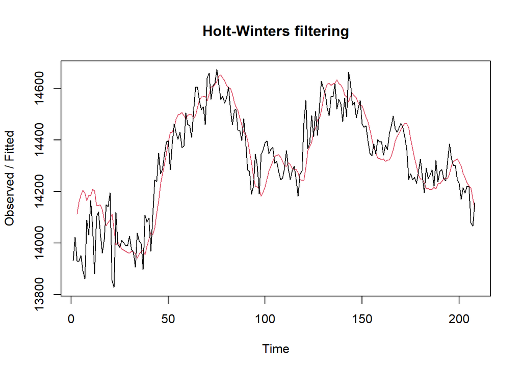

```r
des.1<- HoltWinters(train.ts, gamma = FALSE, beta = 0.2, alpha = 0.2)
plot(des.1)
```

```r
ramalandes1<- forecast(des.1, h=53)
ramalandes1
```

```
##     Point Forecast    Lo 80    Hi 80    Lo 95    Hi 95
## 209       14120.54 13999.49 14241.58 13935.42 14305.66
## 210       14103.17 13978.69 14227.65 13912.79 14293.55
## 211       14085.80 13956.78 14214.81 13888.49 14283.11
## 212       14068.43 13933.72 14203.13 13862.42 14274.44
## 213       14051.06 13909.48 14192.63 13834.54 14267.58
## 214       14033.69 13884.06 14183.31 13804.85 14262.52
## 215       14016.32 13857.49 14175.14 13773.42 14259.21
## 216       13998.95 13829.83 14168.06 13740.30 14257.59
## 217       13981.57 13801.13 14162.02 13705.60 14257.55
## 218       13964.20 13771.44 14156.97 13669.40 14259.01
## 219       13946.83 13740.84 14152.82 13631.80 14261.87
## 220       13929.46 13709.39 14149.54 13592.89 14266.04
## 221       13912.09 13677.13 14147.06 13552.75 14271.44
## 222       13894.72 13644.12 14145.33 13511.45 14277.99
```

[output cut: 39 more lines]

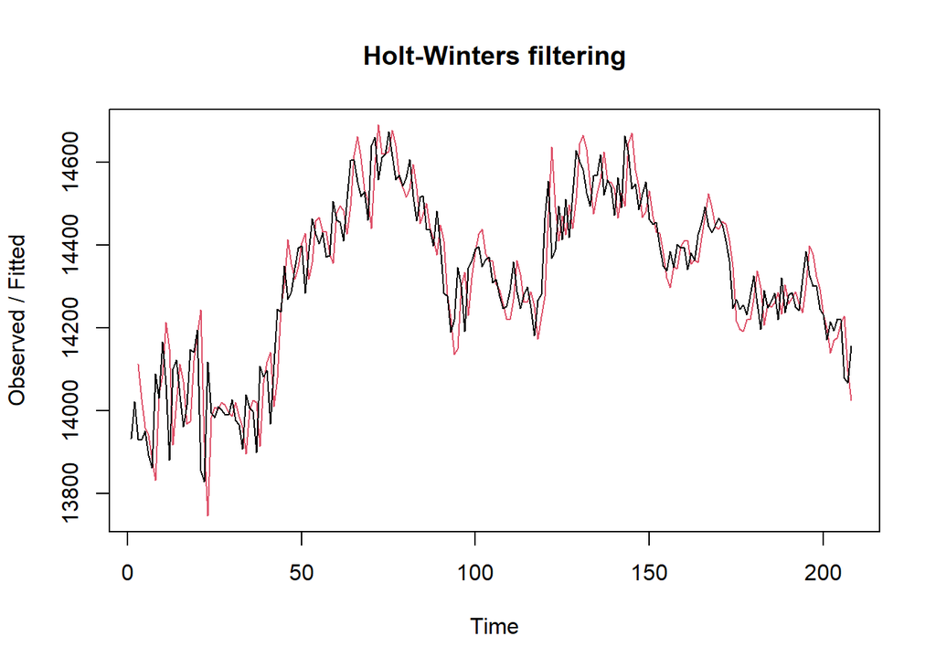

```r
des.2<- HoltWinters(train.ts, gamma = FALSE, beta = 0.6, alpha = 0.6)
plot(des.2)
```

```r
ramalandes2<- forecast(des.2, h=53)
ramalandes2
```

```
##     Point Forecast     Lo 80    Hi 80       Lo 95    Hi 95
## 209       14099.05 13983.455 14214.64 13922.26389 14275.83
## 210       14093.49 13933.255 14253.73 13848.43156 14338.55
## 211       14087.94 13866.674 14309.20 13749.54517 14426.33
## 212       14082.38 13787.985 14376.78 13632.14190 14532.62
## 213       14076.82 13699.633 14454.02 13499.95908 14653.69
## 214       14071.27 13603.042 14539.50 13355.17772 14787.36
## 215       14065.71 13499.128 14632.30 13199.19522 14932.23
## 216       14060.16 13388.528 14731.79 13032.98909 15087.33
## 217       14054.60 13271.723 14837.48 12857.29159 15251.91
## 218       14049.05 13149.089 14949.01 12672.67974 15425.41
## 219       14043.49 13020.935 15066.05 12479.62551 15607.36
## 220       14037.94 12887.520 15188.35 12278.52586 15797.35
## 221       14032.38 12749.067 15315.69 12069.72185 15995.04
## 222       14026.83 12605.772 15447.88 11853.51134 16200.14
```

[output cut: 39 more lines]

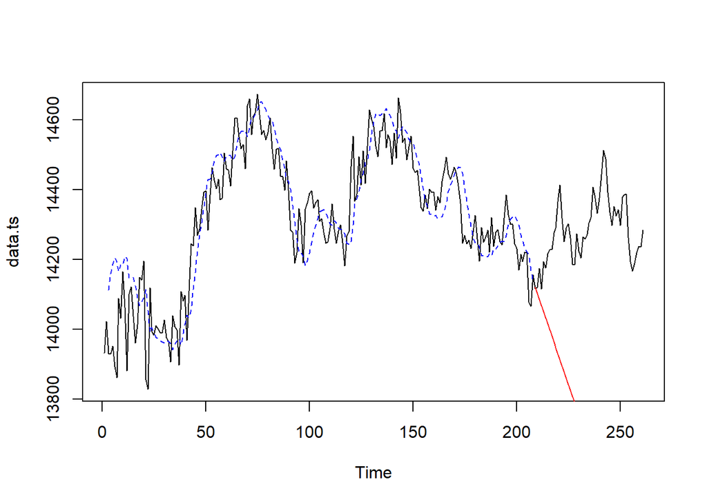

```r
plot(data.ts)
lines(des.1$fitted[,1], lty=2, col="blue")
lines(ramalandes1$mean, col="red")
```

```r
des.opt<- HoltWinters(train.ts, gamma = FALSE)
des.opt
```

```
## Holt-Winters exponential smoothing with trend and without seasonal component.
##
## Call:
## HoltWinters(x = train.ts, gamma = FALSE)
##
## Smoothing parameters:
##  alpha: 0.5857638
##  beta : 0.1287854
##  gamma: FALSE
##
## Coefficients:
##          [,1]
## a 14120.68840
## b   -11.86685
```

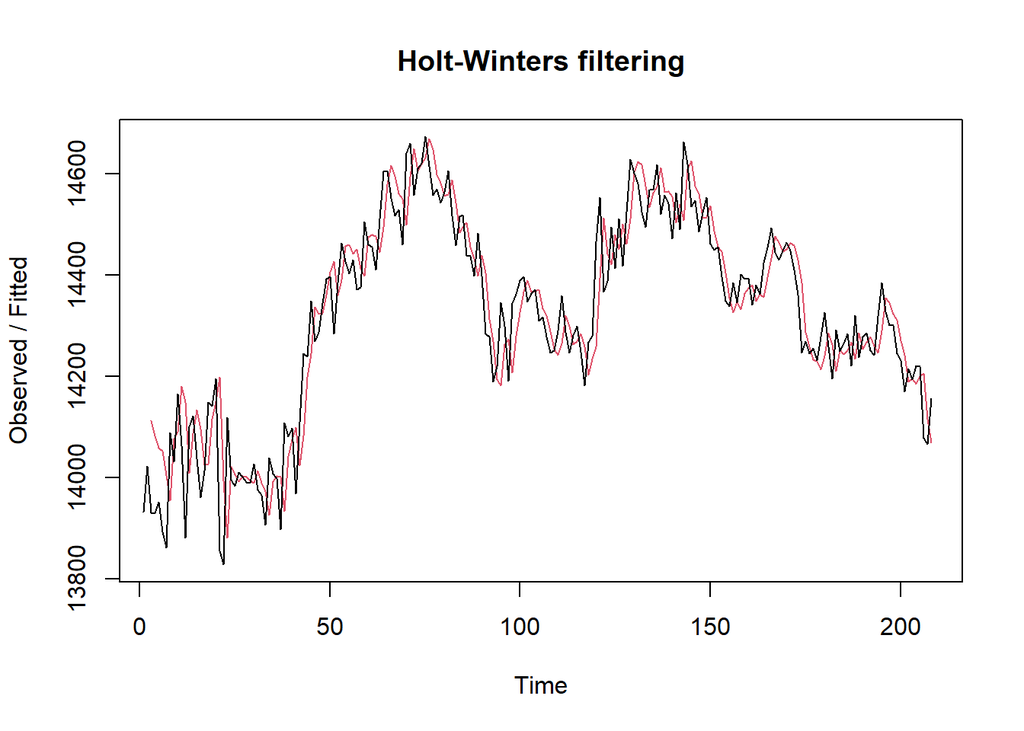

```r
plot(des.opt)
```

```r
ramalandesopt<- forecast(des.opt, h=53)
ramalandesopt
```

```
##     Point Forecast    Lo 80    Hi 80    Lo 95    Hi 95
## 209       14108.82 14007.35 14210.29 13953.64 14264.00
## 210       14096.95 13975.31 14218.60 13910.92 14282.99
## 211       14085.09 13942.32 14227.86 13866.74 14303.44
## 212       14073.22 13908.38 14238.07 13821.11 14325.33
## 213       14061.35 13873.51 14249.19 13774.08 14348.63
## 214       14049.49 13837.75 14261.22 13725.67 14373.31
## 215       14037.62 13801.12 14274.12 13675.92 14399.32
## 216       14025.75 13763.64 14287.87 13624.88 14426.63
## 217       14013.89 13725.33 14302.45 13572.57 14455.20
## 218       14002.02 13686.21 14317.83 13519.03 14485.01
## 219       13990.15 13646.31 14333.99 13464.29 14516.01
## 220       13978.29 13605.65 14350.92 13408.39 14548.19
## 221       13966.42 13564.24 14368.60 13351.34 14581.50
## 222       13954.55 13522.10 14387.00 13293.18 14615.93
```

[output cut: 39 more lines]

Selanjutnya akan dilakukan perhitungan akurasi pada data latih maupun data uji dengan ukuran akurasi SSE, MSE dan MAPE.

```r
ssedes.train1<-des.1$SSE
msedes.train1<-ssedes.train1/length(train.ts)
sisaandes1<-ramalandes1$residuals
head(sisaandes1)
```

```
## Time Series:
## Start = 1
## End = 6
## Frequency = 1
## [1]        NA        NA -181.2275 -229.2603 -235.6157 -311.2978
```

```r
mapedes.train1 <- sum(abs(sisaandes1[3:length(train.ts)]/train.ts[3:length(train.ts)])
                      *100)/length(train.ts)

akurasides.1 <- matrix(c(ssedes.train1,msedes.train1,mapedes.train1))
row.names(akurasides.1)<- c("SSE", "MSE", "MAPE")
colnames(akurasides.1) <- c("Akurasi lamda=0.2 dan gamma=0.2")
akurasides.1
```

```
##      Akurasi lamda=0.2 dan gamma=0.2
## SSE                     1.863879e+06
## MSE                     8.960958e+03
## MAPE                    5.058489e-01
```

```r
mapedes.train1 <- sum(abs(sisaandes1[3:length(train.ts)]/train.ts[3:length(train.ts)])
                      *100)/length(train.ts)

akurasides.1 <- matrix(c(ssedes.train1,msedes.train1,mapedes.train1))
row.names(akurasides.1)<- c("SSE", "MSE", "MAPE")
colnames(akurasides.1) <- c("Akurasi lamda=0.2 dan gamma=0.2")
akurasides.1
```

```
##      Akurasi lamda=0.2 dan gamma=0.2
## SSE                     1.863879e+06
## MSE                     8.960958e+03
## MAPE                    5.058489e-01
```

```r
ssedes.train2<-des.2$SSE
msedes.train2<-ssedes.train2/length(train.ts)
sisaandes2<-ramalandes2$residuals
head(sisaandes2)
```

```
## Time Series:
## Start = 1
## End = 6
## Frequency = 1
## [1]          NA          NA -181.227539  -98.776445   -7.336097  -48.141424
```

```r
mapedes.train2 <- sum(abs(sisaandes2[3:length(train.ts)]/train.ts[3:length(train.ts)])
                      *100)/length(train.ts)

akurasides.2 <- matrix(c(ssedes.train2,msedes.train2,mapedes.train2))
row.names(akurasides.2)<- c("SSE", "MSE", "MAPE")
colnames(akurasides.2) <- c("Akurasi lamda=0.6 dan gamma=0.6")
akurasides.2
```

```
##      Akurasi lamda=0.6 dan gamma=0.6
## SSE                     1.668125e+06
## MSE                     8.019830e+03
## MAPE                    4.575365e-01
```

```r
selisihdes1<-ramalandes1$mean-testing$Close
selisihdes1
```

```
## Time Series:
## Start = 209
## End = 261
## Frequency = 1
##  [1]     3.738447   -16.632010   -89.202661   -47.573118  -142.443575
##  [6]  -142.014226  -200.784097  -230.054944  -246.925401  -312.395467
## [11]  -343.066704  -436.536770  -501.907227  -425.077488  -374.648140
## [16]  -430.018597  -459.789444  -436.459705  -378.830162  -394.900813
## [21]  -501.071075  -468.041141  -466.311988  -544.081858  -555.952315
## [26]  -586.223162  -634.494009  -668.464075  -774.034727  -760.204988
## [31]  -733.575445  -793.945901  -879.116163  -966.686815  -960.057271
## [36]  -880.727532  -839.798184  -819.569031  -891.439488  -881.609749
## [41]  -916.780010  -889.150467  -989.020924 -1012.091575 -1032.462032
## [46]  -925.032684  -872.302555  -863.673011  -902.543468  -950.614119
## [51]  -986.184771 -1002.355033 -1067.925684
```

```r
SSEtestingdes1<-sum(selisihdes1^2)
MSEtestingdes1<-SSEtestingdes1/length(testing$Close)
MAPEtestingdes1<-sum(abs(selisihdes1/testing$Close)*100)/length(testing$Close)

selisihdes2<-ramalandes2$mean-testing$Close
selisihdes2
```

```
## Time Series:
## Start = 209
## End = 261
## Frequency = 1
##  [1]  -17.75281  -26.30834  -87.06407  -33.61960 -116.67513 -104.43086
##  [7] -151.38581 -168.84173 -173.89726 -227.55240 -246.40872 -328.06386
## [13] -381.61939 -292.97473 -230.73045 -274.28599 -292.24191 -257.09725
## [19] -187.65278 -191.90851 -286.26384 -241.41898 -227.87491 -293.82985
## [25] -293.88538 -312.34131 -348.79723 -370.95237 -464.70810 -439.06343
## [31] -400.61897 -449.17450 -522.52984 -598.28556 -579.84110 -488.69643
## [37] -435.95216 -403.90808 -463.96361 -442.31895 -465.67429 -426.22982
## [43] -514.28535 -525.54108 -534.09661 -414.85234 -350.30728 -329.86282
## [49] -356.91835 -393.17408 -416.92980 -421.28514 -475.04087
```

```r
SSEtestingdes2<-sum(selisihdes2^2)
MSEtestingdes2<-SSEtestingdes2/length(testing$Close)
MAPEtestingdes2<-sum(abs(selisihdes2/testing$Close)*100)/length(testing$Close)

selisihdesopt<-ramalandesopt$mean-testing$Close
selisihdesopt
```

```
## Time Series:
## Start = 209
## End = 261
## Frequency = 1
##  [1]   -7.978254  -22.845107  -89.912155  -42.779008 -132.145860 -126.212909
##  [7] -179.479175 -203.246419 -214.613271 -274.579734 -299.747368 -387.713830
## [13] -447.580682 -365.247340 -309.314388 -359.181241 -383.448484 -354.615141
## [19] -291.481994 -302.049042 -402.715700 -364.182162 -356.949405 -429.215672
## [25] -435.582525 -460.349768 -503.117012 -531.583474 -631.650522 -612.317179
## [31] -580.184032 -635.050885 -714.717542 -796.784590 -784.651443 -699.818100
## [37] -653.385148 -627.652392 -694.019244 -678.685902 -708.352559 -675.219412
## [43] -769.586265 -787.153313 -802.020166 -689.087214 -630.853481 -616.720333
## [49] -650.087186 -692.654234 -722.721282 -733.387940 -793.454988
```

```r
SSEtestingdesopt<-sum(selisihdesopt^2)
MSEtestingdesopt<-SSEtestingdesopt/length(testing$Close)
MAPEtestingdesopt<-sum(abs(selisihdesopt/testing$Close)*100)/length(testing$Close)

akurasitestingdes <-
  matrix(c(SSEtestingdes1,MSEtestingdes1,MAPEtestingdes1,SSEtestingdes2,MSEtestingdes2,
           MAPEtestingdes2,SSEtestingdesopt,MSEtestingdesopt,MAPEtestingdesopt),
         nrow=3,ncol=3)
row.names(akurasitestingdes)<- c("SSE", "MSE", "MAPE")
colnames(akurasitestingdes) <- c("des ske1","des ske2","des opt")
akurasitestingdes
```

```
##          des ske1     des ske2      des opt
## SSE  2.515321e+07 6.869349e+06 1.521641e+07
## MSE  4.745889e+05 1.296104e+05 2.871020e+05
## MAPE 4.301834e+00 2.303526e+00 3.382394e+00
```

# Perbandingan SES dan DES

```r
MSEfull <-
  matrix(c(MSEtesting1,MSEtesting2,MSEtestingopt,MSEtestingdes1,MSEtestingdes2,
           MSEtestingdesopt),nrow=3,ncol=2)
row.names(MSEfull)<- c("ske 1", "ske 2", "ske opt")
colnames(MSEfull) <- c("ses","des")
MSEfull
```

```
##               ses      des
## ske 1    8598.228 474588.9
## ske 2   31370.013 129610.4
## ske opt 31576.310 287102.0
```

Kedua metode dapat dibandingkan dengan menggunakan ukuran akurasi yang sama. Contoh di atas adalah perbandingan kedua metode dengan ukuran akurasi MSE. Hasilnya didapatkan metode SES lebih baik dibandingkan metode DES dilihat dari MSE yang lebih kecil nilainya.

```r
## Ringkasan Akurasi Data Uji Tiap Metode

# --- SMA (m = 3) ---
SMA_test <- c(SSE = SSE_test.sma, MSE = MSE_test.sma, MAPE = MAPE_test.sma)

# --- DMA (m = 3) ---
DMA_test <- c(SSE = SSE_test.dma, MSE = MSE_test.dma, MAPE = MAPE_test.dma)

# --- SES (skenario alpha = 0.05, hasil terbaik di data uji) ---
MAPEtesting1 <- mean(abs(e1 / as.numeric(testing$Close)) * 100, na.rm = TRUE)
SES_test <- c(SSE = SSEtesting1, MSE = MSEtesting1, MAPE = MAPEtesting1)

# --- DES/Holt (skenario alpha = 0.6, beta = 0.6, hasil terbaik di data uji) ---
DES_test <- c(SSE = SSEtestingdes2, MSE = MSEtestingdes2, MAPE = MAPEtestingdes2)
```

```r
akurasi_all <- data.frame(
  Metode = c("SMA (m=3)", "DMA (m=3)", "SES (alpha=0.05)", "DES (alpha=0.6, beta=0.6)"),
  SSE    = c(SMA_test["SSE"],  DMA_test["SSE"],  SES_test["SSE"],  DES_test["SSE"]),
  MSE    = c(SMA_test["MSE"],  DMA_test["MSE"],  SES_test["MSE"],  DES_test["MSE"]),
  MAPE   = c(SMA_test["MAPE"], DMA_test["MAPE"], SES_test["MAPE"], DES_test["MAPE"]),
  row.names = NULL
)

# Urutkan dari metode terbaik (MAPE terkecil) ke yang terburuk
akurasi_all <- akurasi_all[order(akurasi_all$MAPE), ]
akurasi_all$SSE  <- round(akurasi_all$SSE, 2)
akurasi_all$MSE  <- round(akurasi_all$MSE, 2)
akurasi_all$MAPE <- round(akurasi_all$MAPE, 3)

akurasi_all
```

```
##                      Metode        SSE        MSE  MAPE
## 3          SES (alpha=0.05)   455706.1    8598.23 0.516
## 1                 SMA (m=3)  2219298.0   41873.55 1.281
## 4 DES (alpha=0.6, beta=0.6)  6869349.4  129610.37 2.304
## 2                 DMA (m=3) 72643436.8 1370630.88 7.354
```

```r
metode_terbaik <- akurasi_all$Metode[which.min(akurasi_all$MAPE)]
cat("Metode terbaik berdasarkan MAPE data uji adalah:", metode_terbaik, "\n")
```

```
## Metode terbaik berdasarkan MAPE data uji adalah: SES (alpha=0.05)
```

Berdasarkan dari berbagai jenis matriks evaluasi yang ada, MAPE terkecil dipilih sebagai indikator optimum dalam pemilihan berbagai metode pemulusan yang ada. Sehingga, pada data USD/IDR 2021 ini, SES dengan alpha 0.05 adalah metode yang terbaik karena memiliki nilai MAPE yang paling kecil yakni sebesar 0,516% yang bisa dikategorikan sebagai tingkat akurasi terbaik.